# Baysian data analysis in R: Introduction

Bayesian inference is a method for figuring out unknown quantities given some known facts. There are other inference methods for this, but what makes Bayesian inference special is that it uses probability to describe the uncertainty. It’s really just about using probability, where probability is a number between 0 and 1. Fundamentally, what Baysian analysis is doing is *updating* the probability distribution to reflect data.

The function prop_model implements a Bayesian model that assumes that: - The data is a vector of successes and failures represented by 1s and 0s. - There is an unknown underlying proportion of success. - Prior to being updated with data, any underlying proportion of success is equally likely.

Let’s start by seeing what happens when we run the model with no data.

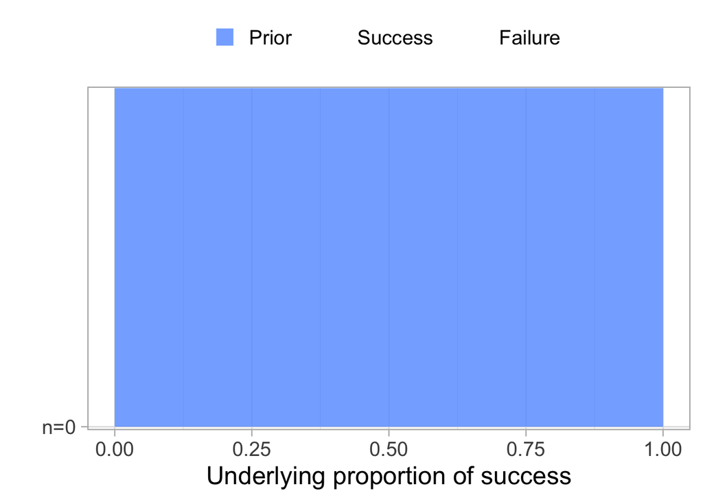

```r
data <- c()
prop_model(data)
```

```r
#The function prop_model implements a Bayesian model that assumes that: 1) The data is a vector of successes and failures represented by 1s and 0s; 2) There is an unknown underlying proportion of success; 3) Prior to being updated with data, any underlying proportion of success is equally likely.
```

We get a big blue square representing a uniform probability distribution, indicating that any proportion of successes has equal probability. It’s labeled “Prior” because one assumption of the model was that **prior** to seeing any data, any underlying proportion of success is equally likely. Now, let’s add a data point: say this is from an experiment on whether a drug cured patients. The first run of the experiment showed that the patient was not cured.

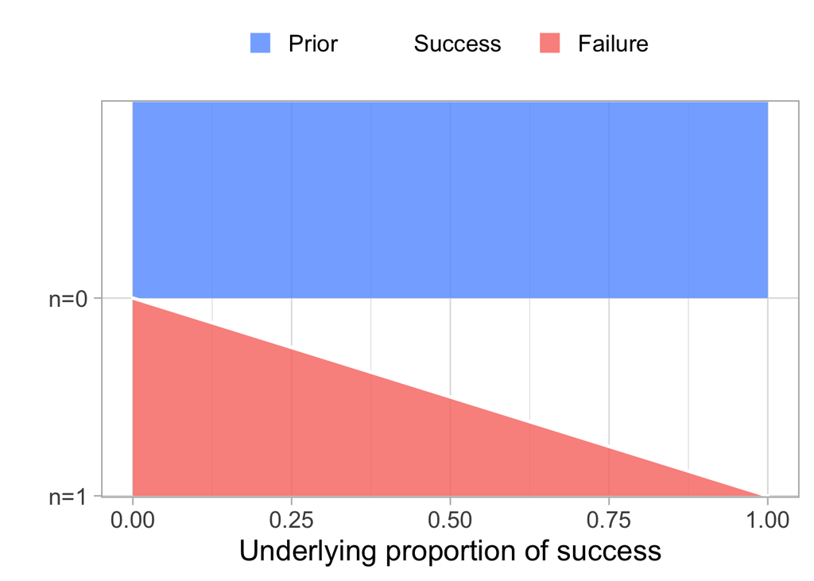

```r
data <- c(0)
prop_model(data)
```

If we re-run the experiment and the second patient was cured, the probability of having a success changes…

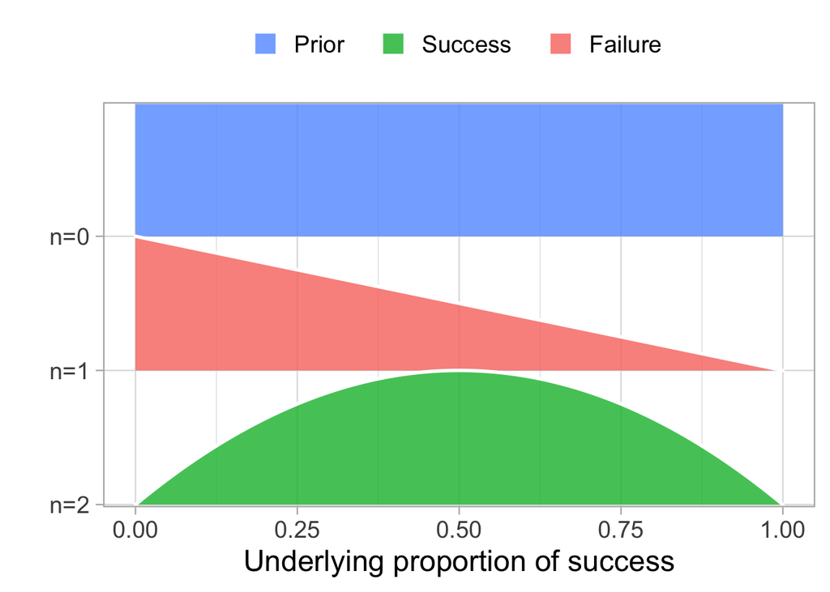

```r
data <- c(0,1)
prop_model(data)
```

Remember, the fundamental idea of Bayesian analysis is that you are updating a prior probability with data to look at increasingly powerful **posterior** probability distributions. So, say we have six data points from the experiment. Now we know that, given an uninformative prior with equal likelihood of success/failure, the probability of being cured from the drug is approximately 40%, with substantial uncertainty, as the drug’s efficacy could range from approximately 10% to 70%.

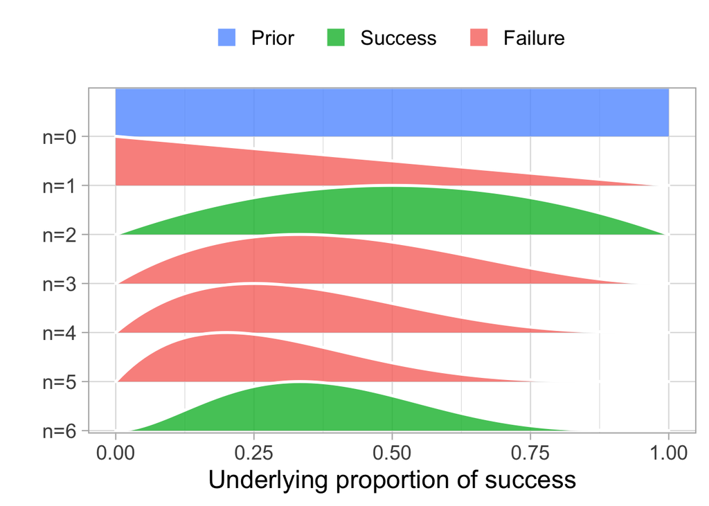

```r
data <- c(0,1,0,0,0,1)
prop_model(data)
```

**CONGRATULATIONS, you’ve just used a Bayesian model!**